# Analyzing Data

Michael Dumelle, Tom Kincaid, Anthony Olsen, and Marc Weber

If you have yet not read the “Start Here” vignette, please do so by running

```r
vignette("start-here", "spsurvey")
```

# 1 Introduction

spsurvey’s analysis functions are used to analyze data in a variety of contexts. We focus mainly on using the `NLA_PNW` analysis data to introduce some of these analysis functions. The `NLA_PNW` data contains response variables measured at several lakes in the Pacific Northwest Region (PNW) of the United States. There are several variables in `NLA_PNW` you will use throughout this vignette:

- `SITE_ID`: a unique site identifier
- `WEIGHT`: the design weights
- `URBAN`: urban land categories (`Urban` and `Non-Urban`)
- `STATE`: state name (`California`, `Oregon`, and `Washington`)
- `BMMI`: benthic macroinvertebrate multi-metric index
- `BMMI_COND`: benthic macroinvertebrate multi-metric index condition categories (`Poor` and `Good`)
- `PHOS_COND`: phosphorous condition categories (`Poor` and `Good`)
- `NITR_COND`: nitrogen condition categories (`Poor` `Fair`, and `Good`)

Before proceeding, we load spsurvey by running

```r
library(spsurvey)
```

# 2 Categorical Variable Analysis

Categorical variables are analyzed in spsurvey using the `cat_analysis()` function. The `cat_analysis()` function estimates the proportion of observations and the total units (i.e. extent) that belong to each level of the categorical variable (total units refer to the total number (point resources), total line length (linear network), or total area (areal network)). Several useful pieces of information are returned by `cat_analysis()`, including estimates, standard errors, margins of error, and confidence intervals. The analysis results contain columns with a `.P` and `.U` suffixes. The `.P` suffix corresponds to estimates of proportions for each category, while the `.U` suffix corresponds to estimates of total units (i.e. extent) for each category.

## 2.1 Unstratified Analysis

To estimate the proportion of total lakes in each nitrogen condition category and the total number of lakes in each nitrogen condition category, run

```r
cat_ests <- cat_analysis(
  NLA_PNW,
  siteID = "SITE_ID",
  vars = "NITR_COND",
  weight = "WEIGHT"
)
cat_ests
```

```
#>        Type Subpopulation Indicator Category nResp Estimate.P StdError.P
#> 1 All_Sites     All Sites NITR_COND     Fair    24   23.69392   6.194024
#> 2 All_Sites     All Sites NITR_COND     Good    38   51.35111   7.430172
#> 3 All_Sites     All Sites NITR_COND     Poor    34   24.95496   5.919180
#> 4 All_Sites     All Sites NITR_COND    Total    96  100.00000   0.000000
#>   MarginofError.P LCB95Pct.P UCB95Pct.P Estimate.U StdError.U MarginofError.U
#> 1        12.14006   11.55386   35.83399   2530.428   693.5593        1359.351
#> 2        14.56287   36.78824   65.91398   5484.120  1223.3708        2397.763
#> 3        11.60138   13.35359   36.55634   2665.103   658.0966        1289.846
#> 4         0.00000  100.00000  100.00000  10679.652  1416.2707        2775.840
#>   LCB95Pct.U UCB95Pct.U
#> 1   1171.077   3889.780
#> 2   3086.357   7881.883
#> 3   1375.258   3954.949
#> 4   7903.812  13455.491
```

The estimate of the proportion of lakes in `Good` condition is 51.35% with a 95% confidence interval of (36.8%, 65.9%), while the estimate of the total number of lakes in `Good` condition is 5484 lakes with a 95% confidence interval of (3086, 7882). In each case, the estimated standard error and margin of error is given. The confidence level can be changed using the `conf` argument. If more than one categorical variable is of interest, then `vars` can be a vector of variables and separate analyses are performed for each variable.

Sometimes the goal is to estimate proportions and totals separately for different subsets of the population – these subsets are called subpopulations. To estimate the proportion of total lakes and in each nitrogen condition category the total number of lakes in each nitrogen condition category separately for `California`, `Oregon`, and `Washington` lakes, run

```r
cat_ests_sp <- cat_analysis(
  NLA_PNW,
  siteID = "SITE_ID",
  vars = "NITR_COND",
  weight = "WEIGHT",
  subpop = "STATE"
)
cat_ests_sp
```

```
#>     Type Subpopulation Indicator Category nResp Estimate.P StdError.P
#> 1  STATE    California NITR_COND     Fair     6   8.239162   4.712515
#> 2  STATE    California NITR_COND     Good     8  73.722638  13.359879
#> 3  STATE    California NITR_COND     Poor     5  18.038200  11.909638
#> 4  STATE    California NITR_COND    Total    19 100.000000   0.000000
#> 5  STATE        Oregon NITR_COND     Fair     8  27.152211   9.763817
#> 6  STATE        Oregon NITR_COND     Good    26  59.670307   9.717093
#> 7  STATE        Oregon NITR_COND     Poor    13  13.177483   4.901892
#> 8  STATE        Oregon NITR_COND    Total    47 100.000000   0.000000
#> 9  STATE    Washington NITR_COND     Fair    10  30.396139  11.938582
#> 10 STATE    Washington NITR_COND     Good     4  22.711979  11.878964
#> 11 STATE    Washington NITR_COND     Poor    16  46.891882  13.041148
#> 12 STATE    Washington NITR_COND    Total    30 100.000000   0.000000
#>    MarginofError.P LCB95Pct.P UCB95Pct.P Estimate.U StdError.U MarginofError.U
#> 1         9.236359   0.000000   17.47552   208.4605   87.63415        171.7598
```

[output cut: 24 more lines]

If more than one type of subpopulation is of interest, then `subpop` can be a vector of subpopulation variables and separate analyses are performed for each subpopulation. If both `vars` and `subpops` are vectors, separate analyses are performed for each variable and subpopulation combination.

Analysis results for all sites (ignoring subpopulations) can be presented alongside the subpopulation analysis results using the `All_Sites` argument:

```r
cat_ests_sp <- cat_analysis(
  NLA_PNW,
  siteID = "SITE_ID",
  vars = "NITR_COND",
  weight = "WEIGHT",
  subpop = "STATE",
  All_Sites = TRUE
)
cat_ests_sp
```

```
#>         Type Subpopulation Indicator Category nResp Estimate.P StdError.P
#> 1      STATE    California NITR_COND     Fair     6   8.239162   4.712515
#> 2      STATE    California NITR_COND     Good     8  73.722638  13.359879
#> 3      STATE    California NITR_COND     Poor     5  18.038200  11.909638
#> 4      STATE    California NITR_COND    Total    19 100.000000   0.000000
#> 5      STATE        Oregon NITR_COND     Fair     8  27.152211   9.763817
#> 6      STATE        Oregon NITR_COND     Good    26  59.670307   9.717093
#> 7      STATE        Oregon NITR_COND     Poor    13  13.177483   4.901892
#> 8      STATE        Oregon NITR_COND    Total    47 100.000000   0.000000
#> 9      STATE    Washington NITR_COND     Fair    10  30.396139  11.938582
#> 10     STATE    Washington NITR_COND     Good     4  22.711979  11.878964
#> 11     STATE    Washington NITR_COND     Poor    16  46.891882  13.041148
#> 12     STATE    Washington NITR_COND    Total    30 100.000000   0.000000
#> 13 All_Sites     All Sites NITR_COND     Fair    24  23.693923   6.194024
#> 14 All_Sites     All Sites NITR_COND     Good    38  51.351112   7.430172
```

[output cut: 36 more lines]

## 2.2 Stratified Analysis

To estimate the proportion of total lakes in each nitrogen condition category and the total number of lakes in each nitrogen condition category stratified by `URBAN` category (whether the lake is classified as `Urban` or `Non-Urban`), run

```r
strat_cat_ests <- cat_analysis(
  NLA_PNW,
  siteID = "SITE_ID",
  vars = "NITR_COND",
  weight = "WEIGHT",
  stratumID = "URBAN"
)
strat_cat_ests
```

```
#>        Type Subpopulation Indicator Category nResp Estimate.P StdError.P
#> 1 All_Sites     All Sites NITR_COND     Fair    24   23.69392   6.027083
#> 2 All_Sites     All Sites NITR_COND     Good    38   51.35111   7.472377
#> 3 All_Sites     All Sites NITR_COND     Poor    34   24.95496   5.882487
#> 4 All_Sites     All Sites NITR_COND    Total    96  100.00000   0.000000
#>   MarginofError.P LCB95Pct.P UCB95Pct.P Estimate.U StdError.U MarginofError.U
#> 1        11.81287   11.88106   35.50679   2530.428   683.8837        1340.387
#> 2        14.64559   36.70552   65.99670   5484.120  1229.9485        2410.655
#> 3        11.52946   13.42550   36.48443   2665.103   653.6357        1281.102
#> 4         0.00000  100.00000  100.00000  10679.652  1440.4796        2823.288
#>   LCB95Pct.U UCB95Pct.U
#> 1   1190.041   3870.816
#> 2   3073.465   7894.775
#> 3   1384.001   3946.206
#> 4   7856.363  13502.940
```

To then compute these estimates separately for `California`, `Oregon`, and `Washington`, run

```r
strat_cat_ests_sp <- cat_analysis(
  NLA_PNW,
  siteID = "SITE_ID",
  vars = "NITR_COND",
  weight = "WEIGHT",
  stratumID = "URBAN",
  subpop = "STATE"
)
strat_cat_ests_sp
```

```
#>     Type Subpopulation Indicator Category nResp Estimate.P StdError.P
#> 1  STATE    California NITR_COND     Fair     6   8.239162   5.481100
#> 2  STATE    California NITR_COND     Good     8  73.722638  13.653267
#> 3  STATE    California NITR_COND     Poor     5  18.038200  12.512366
#> 4  STATE    California NITR_COND    Total    19 100.000000   0.000000
#> 5  STATE        Oregon NITR_COND     Fair     8  27.152211   9.592356
#> 6  STATE        Oregon NITR_COND     Good    26  59.670307   9.845022
#> 7  STATE        Oregon NITR_COND     Poor    13  13.177483   5.325784
#> 8  STATE        Oregon NITR_COND    Total    47 100.000000   0.000000
#> 9  STATE    Washington NITR_COND     Fair    10  30.396139  11.383474
#> 10 STATE    Washington NITR_COND     Good     4  22.711979   9.039351
#> 11 STATE    Washington NITR_COND     Poor    16  46.891882  12.109215
#> 12 STATE    Washington NITR_COND    Total    30 100.000000   0.000000
#>    MarginofError.P LCB95Pct.P UCB95Pct.P Estimate.U StdError.U MarginofError.U
#> 1         10.74276   0.000000   18.98192   208.4605   87.91849        172.3171
```

[output cut: 24 more lines]

# 3 Continuous Variable Analysis

Continuous variables are analyzed in spsurvey using the `cont_analysis()` function. The `cont_analysis()` function estimates cumulative distribution functions (CDFs), percentiles, and means of continuous variables. By default, all these quantities are estimated (though this can be changed using the `statsitics` argument to `cont_analysis()`). For the quantities requiring estimation, several useful pieces of information are returned by `cont_analysis()`, including estimates, standard errors, margins of error, and confidence intervals. The `.P` suffix corresponds to estimates of proportions for each variable, while the `.U` suffix corresponds to estimates of total units (i.e. extent) for each variable.

## 3.1 Unstratified Analysis

To estimate the cumulative distribution function (CDF), certain percentiles, and means of `BMMI`, run

```r
cont_ests <- cont_analysis(
  NLA_PNW,
  siteID = "SITE_ID",
  vars = "BMMI",
  weight = "WEIGHT"
)
```

To view the analysis results for the mean estimates, run

```r
cont_ests$Mean
```

```
#>        Type Subpopulation Indicator nResp Estimate StdError MarginofError
#> 1 All_Sites     All Sites      BMMI    96 56.50929 1.782278        3.4932
#>   LCB95Pct UCB95Pct
#> 1 53.01609 60.00249
```

Similarly, the CDF and select percentile estimates can be viewed (the output is omitted here) by running

```r
cont_ests$CDF
cont_ests$Pct
```

To visualize the CDF estimates, run

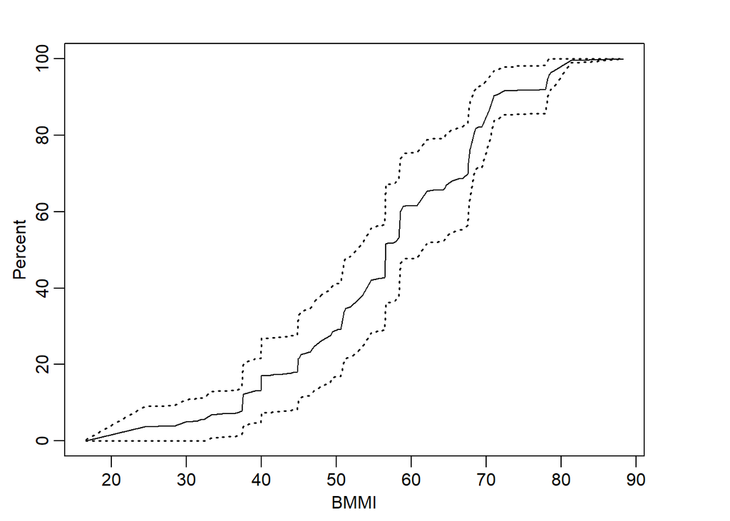

```r
plot(cont_ests$CDF)
```

The solid line indicates the CDF estimates, and the dashed lines indicate lower and upper 95% confidence interval bounds for the CDF estimates. `cdf_plot()` can equivalently be used in place of `plot()` (`cdf_plot()` is currently maintained for backwards compatibility with previous spsurvey versions).

To estimate the CDF, certain percentiles, and means of `BMMI` separately for each state, run

```r
cont_ests_sp <- cont_analysis(
  NLA_PNW,
  siteID = "SITE_ID",
  vars = "BMMI",
  weight = "WEIGHT",
  subpop = "STATE"
)
```

To view the analysis results for the mean estimates, run

```r
cont_ests_sp$Mean
```

```
#>    Type Subpopulation Indicator nResp Estimate StdError MarginofError LCB95Pct
#> 1 STATE    California      BMMI    19 50.48964 4.049094      7.936079 42.55357
#> 2 STATE        Oregon      BMMI    47 61.29675 2.581032      5.058730 56.23802
#> 3 STATE    Washington      BMMI    30 54.23036 3.143924      6.161977 48.06838
#>   UCB95Pct
#> 1 58.42572
#> 2 66.35548
#> 3 60.39234
```

## 3.2 Stratified Analysis

To estimate the CDF, certain percentiles, and means of `BMMI` for a design stratified by `URBAN` category, run

```r
strat_cont_ests <- cont_analysis(
  NLA_PNW,
  siteID = "SITE_ID",
  vars = "BMMI",
  weight = "WEIGHT",
  stratumID = "URBAN"
)
```

To view the analysis results for the mean estimates, run

```r
strat_cont_ests$Mean
```

```
#>        Type Subpopulation Indicator nResp Estimate StdError MarginofError
#> 1 All_Sites     All Sites      BMMI    96 56.50929 1.795959      3.520015
#>   LCB95Pct UCB95Pct
#> 1 52.98928 60.02931
```

To then compute these estimates separately for each state, run

```r
strat_cont_ests_sp <- cont_analysis(
  NLA_PNW,
  siteID = "SITE_ID",
  vars = "BMMI",
  weight = "WEIGHT",
  stratumID = "URBAN",
  subpop = "STATE",
)
```

To view the analysis results for the mean estimates, run

```r
strat_cont_ests_sp$Mean
```

```
#>    Type Subpopulation Indicator nResp Estimate StdError MarginofError LCB95Pct
#> 1 STATE    California      BMMI    19 50.48964 4.110046      8.055543 42.43410
#> 2 STATE        Oregon      BMMI    47 61.29675 1.630357      3.195441 58.10131
#> 3 STATE    Washington      BMMI    30 54.23036 2.930517      5.743708 48.48665
#>   UCB95Pct
#> 1 58.54519
#> 2 64.49219
#> 3 59.97407
```

# 4 Additional Analysis Approaches

Alongside the `cat_analysis()` and `cont_analysis()` functions, spsurvey offers functions for estimating attributable risk, relative risk, risk difference, change, and trend. Attributable risk analysis, relative risk analysis, and risk difference analysis quantify the attributable risk, relative risk, and risk difference, respectively, of environmental resources being in poor condition after exposure to a stressor. Attributable risk analysis is performed using the `attrisk_analysis()` function, relative risk analysis is performed using the `relrisk_analysis()` function, and risk difference analysis is performed using the `diffrisk_analysis()` function. Change and trend analysis capture the behavior of environmental resources between two samples, while trend analysis generalizes this approach to include more than two samples. Often, change and trend analyses are performed to study an environmental resource through time. Change analysis is performed using the `change_analysis()` function, and trend analysis is performed using the `trend_analysis()` function. The `attrisk_analysis()`, `relrisk_analysis()`, `diffrisk_analysis()`, `change_analysis()` and `trend_analysis()` functions all share very similar syntax with the `cat_analysis()` and `cont_analysis()` functions.

## 4.1 Attributable Risk, Relative Risk, and Risk Difference Analysis

The attributable risk is defined as
$$1
- \frac{P(Response = Poor | Stressor = Good)}{P(Response =
Poor)},$$
where $P(\cdot)$ is a probability and $P(\cdot | \cdot)$ is a conditional probability. The attributable risk measures the proportion of the response variable in poor condition that could be eliminated if the stressor was always in good condition. To estimate the attributable risk of benthic macroinvertebrates with a phosphorous condition stressor, run

```r
attrisk_ests <- attrisk_analysis(
  NLA_PNW,
  siteID = "SITE_ID",
  vars_response = "BMMI_COND",
  vars_stressor = "PHOS_COND",
  weight = "WEIGHT"
)
attrisk_ests
```

```
#>        Type Subpopulation  Response  Stressor nResp  Estimate StdError_log
#> 1 All_Sites     All Sites BMMI_COND PHOS_COND    96 0.6201042     0.624808
#>   MarginofError_log  LCB95Pct  UCB95Pct WeightTotal Count_RespPoor_StressPoor
#> 1          1.224601 -0.292713 0.8883582    10679.65                         5
#>   Count_RespPoor_StressGood Count_RespGood_StressPoor Count_RespGood_StressGood
#> 1                         7                        18                        66
#>   Prop_RespPoor_StressPoor Prop_RespPoor_StressGood Prop_RespGood_StressPoor
#> 1               0.03971418               0.01738181                 0.158931
#>   Prop_RespGood_StressGood
#> 1                 0.783973
```

The relative risk is defined as
$$\frac{P(Response = Poor | Stressor =
Poor)}{P(Response = Poor | Stressor = Good)},$$
which measures the risk of the response variable being in poor condition relative to the stressor’s condition. To estimate the relative risk of benthic macroinvertebrates being in poor condition with a phosphorous condition category stressor, run

```r
relrisk_ests <- relrisk_analysis(
  NLA_PNW,
  siteID = "SITE_ID",
  vars_response = "BMMI_COND",
  vars_stressor = "PHOS_COND",
  weight = "WEIGHT"
)
relrisk_ests
```

```
#>        Type Subpopulation  Response  Stressor nResp Estimate Estimate_num
#> 1 All_Sites     All Sites BMMI_COND PHOS_COND    96 9.217166    0.1999252
#>   Estimate_denom StdError_log MarginofError_log LCB95Pct UCB95Pct WeightTotal
#> 1     0.02169053    0.8753855          1.715724 1.657555 51.25389    10679.65
#>   Count_RespPoor_StressPoor Count_RespPoor_StressGood Count_RespGood_StressPoor
#> 1                         5                         7                        18
#>   Count_RespGood_StressGood Prop_RespPoor_StressPoor Prop_RespPoor_StressGood
#> 1                        66               0.03971418               0.01738181
#>   Prop_RespGood_StressPoor Prop_RespGood_StressGood
#> 1                 0.158931                 0.783973
```

The risk difference is defined as
$$P(Response = Poor | Stressor = Poor) - P(Response
= Poor | Stressor = Good),$$
which measures the risk of the response variable being in poor condition differenced by the stressor’s condition. To estimate the risk difference of benthic macroinvertebrates being in poor condition with a phosphorous condition category stressor, run

```r
diffrisk_ests <- diffrisk_analysis(
  NLA_PNW,
  siteID = "SITE_ID",
  vars_response = "BMMI_COND",
  vars_stressor = "PHOS_COND",
  weight = "WEIGHT"
)
diffrisk_ests
```

```
#>        Type Subpopulation  Response  Stressor nResp  Estimate
#> 1 All_Sites     All Sites BMMI_COND PHOS_COND    96 0.1782347
#>   Estimate_StressPoor Estimate_StressGood  StdError MarginofError   LCB95Pct
#> 1           0.1999252          0.02169053 0.1139557      0.223349 -0.0451143
#>    UCB95Pct WeightTotal Count_RespPoor_StressPoor Count_RespPoor_StressGood
#> 1 0.4015837    10679.65                         5                         7
#>   Count_RespGood_StressPoor Count_RespGood_StressGood Prop_RespPoor_StressPoor
#> 1                        18                        66               0.03971418
#>   Prop_RespPoor_StressGood Prop_RespGood_StressPoor Prop_RespGood_StressGood
#> 1               0.01738181                 0.158931                 0.783973
```

By default, the levels of the variables in `vars_response` and `vars_stressor` are assumed to equal `"Poor"` (event occurs) or `"Good"` (event does not occur). If those default levels do not match the levels of the variables in `vars_response` and `vars_stressor`, the levels of `vars_response` and `vars_stressor` must be explicitly stated using the `response_levels` and `stressor_levels` arguments, respectively. Similar to `cat_analysis()` and `cont_analysis()` from the previous sections, subpopulations and stratification are incorporated using `subpops` and `stratumID`, respectively. For more on attributable and relative risk in an environmental resource context, see Van Sickle and Paulsen (2008).

## 4.2 Change and Trend Analysis

To demonstrate change analysis, we use the `NRSA_EPA7` data. There are several variables in `NRSA_EPA7` you will use next:

- `SITE_ID`: a unique site identifier
- `WEIGHT`: the survey design weights
- `NITR_COND`: nitrogen condition category (`Good`, `Fair`, and `Poor`)
- `BMMI`: benthic macroinvertebrate multi-metric index
- `YEAR`: probability sample (survey) year

To estimate the change between samples (time points) for `BMMI` (a continuous variable) and `NITR_COND` (a categorical variable), run

```r
change_ests <- change_analysis(
  NRSA_EPA7,
  siteID = "SITE_ID",
  vars_cont = "BMMI",
  vars_cat = "NITR_COND",
  surveyID = "YEAR",
  weight = "WEIGHT"
)
```

The `surveyID` argument is the variable in the data distinguishing the different samples (`YEAR` in the previous example).

To view the analysis results for `NITR_COND` (the categorical variable), run

```r
change_ests$catsum
```

```
#>   Survey_1 Survey_2      Type Subpopulation Indicator     Category  DiffEst.P
#> 1  2008-09  2013-14 All_Sites     All Sites NITR_COND         Fair -1.8867976
#> 2  2008-09  2013-14 All_Sites     All Sites NITR_COND         Good -2.9648182
#> 3  2008-09  2013-14 All_Sites     All Sites NITR_COND Not Assessed -0.2447633
#> 4  2008-09  2013-14 All_Sites     All Sites NITR_COND         Poor  5.0963791
#>   StdError.P MarginofError.P  LCB95Pct.P UCB95Pct.P  DiffEst.U StdError.U
#> 1  3.5366139       6.9316358  -8.8184334  5.0448382 -2919.8839  4990.4714
#> 2  4.7633367       9.3359683 -12.3007865  6.3711502 -4597.9365  6772.4175
#> 3  0.2072643       0.4062305  -0.6509938  0.1614672  -363.1305   306.1656
#> 4  5.8020788      11.3718655  -6.2754864 16.4682446  6598.4548 19777.9218
#>   MarginofError.U LCB95Pct.U UCB95Pct.U nResp_1 Estimate.P_1 StdError.P_1
#> 1       9781.1441 -12701.028   6861.260      37   11.2929433    2.7579622
#> 2      13273.6943 -17871.631   8675.758      22   18.5076549    3.6712147
#> 3        600.0735   -963.204    236.943       1    0.2447633    0.2072643
#> 4      38764.0144 -32165.560  45362.469     119   69.9546385    4.3636869
```

[output cut: 20 more lines]

Estimates are provided for the difference between the two samples and for each of the two individual samples (the `_1` and `_2` suffixes).

To view the analysis results for `BMMI` (the continuous variable), run

```r
change_ests$contsum_mean
```

```
#>   Survey_1 Survey_2      Type Subpopulation Indicator  DiffEst StdError
#> 1  2008-09  2013-14 All_Sites     All Sites      BMMI 3.971559 2.561155
#>   MarginofError  LCB95Pct UCB95Pct nResp_1 Estimate_1 StdError_1
#> 1      5.019771 -1.048211  8.99133     179   25.88274   1.468744
#>   MarginofError_1 LCB95Pct_1 UCB95Pct_1 nResp_2 Estimate_2 StdError_2
#> 1        2.878686   23.00405   28.76142     174    29.8543   2.098166
#>   MarginofError_2 LCB95Pct_2 UCB95Pct_2
#> 1        4.112331   25.74196   33.96663
```

Though we don’t show an example here, the median can be estimated using the `test` argument in `change_anlaysis()`.

Trend analysis generalizes change analysis to more than two samples (usually time points). Though we omit an example here, the arguments to `trend_analysis()` are very similar to the arguments for `change_analysis()`. One difference is that `trend_analysis()` contains arguments that specify which statistical model to apply to the estimates from each sample.

# 5 Variance Estimation

The default variance estimator in spsurvey is the local neighborhood variance estimator (Stevens and Olsen, 2003). The local neighborhood variance estimator incorporates the spatial locations of design sites into the variance estimation process. Because the local neighborhood variance estimator incorporates spatial locations, the resulting variance estimate tends to be smaller than variance estimates from approaches ignoring spatial locations. The local neighborhood variance estimator requires x-coordinates and y-coordinates of the design sites. When the analysis data is an `sf` object, the coordinates from the data’s geometry are used. When the analysis data is just a data frame, x-coordinates and y-coordinates (from an appropriate coordinate reference system) must be provided using the `xcoord` and `ycoord` arguments, respectively, of the analysis function being used.

Several additional variance estimation options are available in spsurvey’s analysis functions through the `vartype` and `jointprob` arguments.

# 6 References

Sickle, J. V., & Paulsen, S. G. (2008). Assessing the attributable risks, relative risks, and regional extents of aquatic stressors. *Journal of the North American Benthological Society*, 27(4), 920-931.

Stevens Jr, D. L., & Olsen, A. R. (2003). Variance estimation for spatially balanced samples of environmental resources. *Environmetrics*, 14(6), 593-610.